# Time Series

A time series is typically defined as an ordered sequence of values that are usually equally spaced over time.

[figure not shown]

$$y_1,...,y_T,..., y_t \in \mathbb{R}$$

To forecast we need to find a function $\mathit{f_T}$: $y_{T+d} \approx \mathit{f_T}(y_T,...,y_1,d) \equiv \hat{y}_{T+d|T}$, where $d \mathbb{1,...,D}$ D forecast horizon.

**Patterns in Time Series**:

- Trend and seasonality.
- Noise.
- Autocorrelated time series.
- Trend + Seasonality + Autocorrelation + Noise
- Non-Stationary Time Series

**Classical Time Series Forecasting Methods**:

- Autoregression (AR)
- Moving Average (MA)
- Autoregressive Moving Average (ARMA)
- Autoregressive Integrated Moving Average (ARIMA)
- Seasonal Autoregressive Integrated Moving-Average (SARIMA)
- Seasonal Autoregressive Integrated Moving-Average with Exogenous Regressors (SARIMAX)
- Vector Autoregression (VAR)
- Vector Autoregression Moving-Average (VARMA)
- Vector Autoregression Moving-Average with Exogenous Regressors (VARMAX)
- Simple Exponential Smoothing (SES)
- Holt Winter’s Exponential Smoothing (HWES)

## Trend and seasonality

```python
import numpy as np                               # vectors and matrices
import pandas as pd                              # tables and data manipulations
import matplotlib.pyplot as plt                  # plots
from matplotlib.pylab import rcParams
import seaborn as sns                            # more plots
sns.set()

from dateutil.relativedelta import relativedelta # working with dates with style
from scipy.optimize import minimize              # for function minimization

import statsmodels.formula.api as smf            # statistics and econometrics
import statsmodels.tsa.api as smt
import statsmodels.api as sm
import scipy.stats as scs

from itertools import product                    # some useful functions
from tqdm import tqdm_notebook

import warnings                                  # `do not disturbe` mode
warnings.filterwarnings('ignore')

%matplotlib inline

rcParams['figure.figsize'] = 10, 6
```

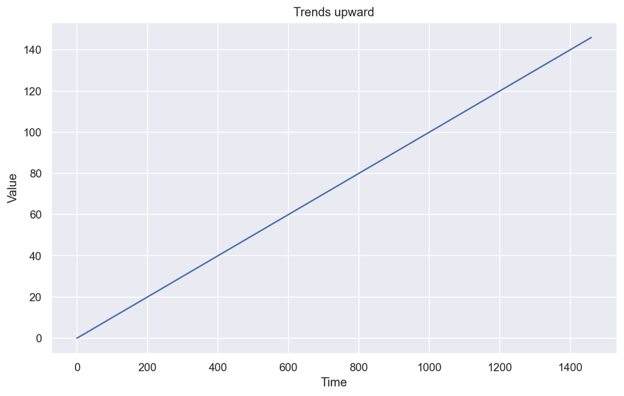

```python
def plot_series(time, series, format="-", start=0, end=None, label=None):
    plt.plot(time[start:end], series[start:end], format, label=label)
    plt.xlabel("Time")
    plt.ylabel("Value")
    if label:
        plt.legend(fontsize=14)
    plt.grid(True)

def trend(time, slope=0):
    return slope * time

time = np.arange(4 * 365 + 1)
baseline = 10
series = trend(time, 0.1)

plt.title("Trends upward")
plot_series(time, series)
plt.show()
```

```python
def seasonal_pattern(season_time):
    """Just an arbitrary pattern, you can change it if you wish"""
    return np.where(season_time < 0.4,
                    np.cos(season_time * 2 * np.pi),
                    1 / np.exp(3 * season_time))

def seasonality(time, period, amplitude=1, phase=0):
    """Repeats the same pattern at each period"""
    season_time = ((time + phase) % period) / period
    return amplitude * seasonal_pattern(season_time)
```

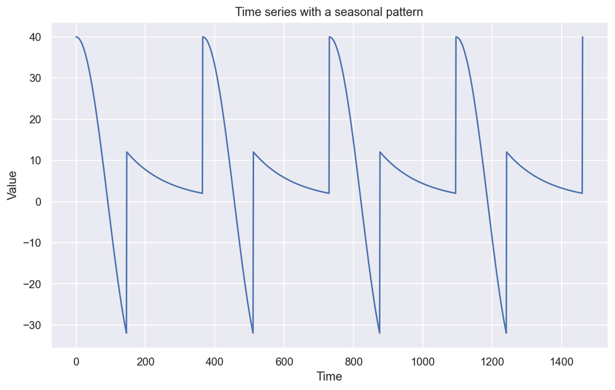

```python
baseline = 10
amplitude = 40
series = seasonality(time, period=365, amplitude=amplitude)

plt.title("Time series with a seasonal pattern")
plot_series(time, series)
plt.show()
```

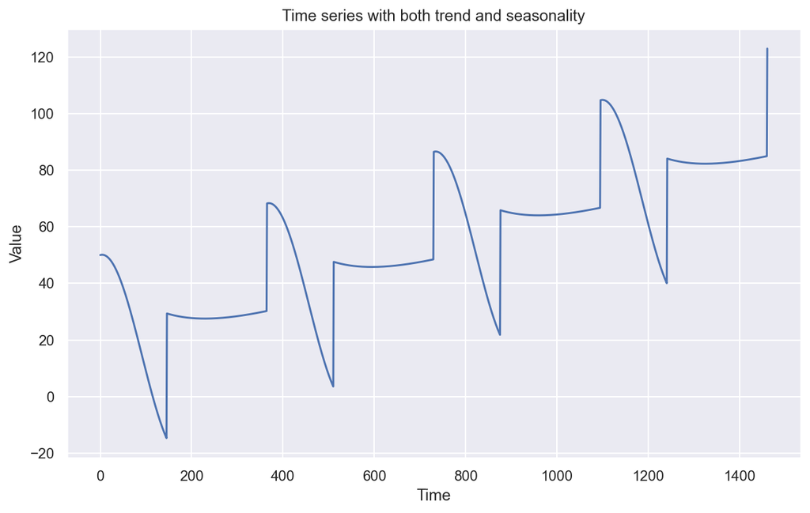

```python
slope = 0.05
series = baseline + trend(time, slope) + seasonality(time, period=365, amplitude=amplitude)

plt.title("Time series with both trend and seasonality")
plot_series(time, series)
plt.show()
```

## Noise

Real-life time series have noise, and the signal-to-noise ratio can sometimes be very low. If a time series is white noise, it is a sequence of random numbers and cannot be predicted. If the series of forecast errors are not white noise, it suggests improvements could be made to the predictive model.

A time series is white noise if the variables are independent and identically distributed with a mean of zero.

This means that all variables have the same variance ($\sigma_2$) and each value has a zero correlation with all other values in the series.

```python
def white_noise(time, noise_level=1, seed=None):
    rnd = np.random.RandomState(seed)
    return rnd.randn(len(time)) * noise_level
```

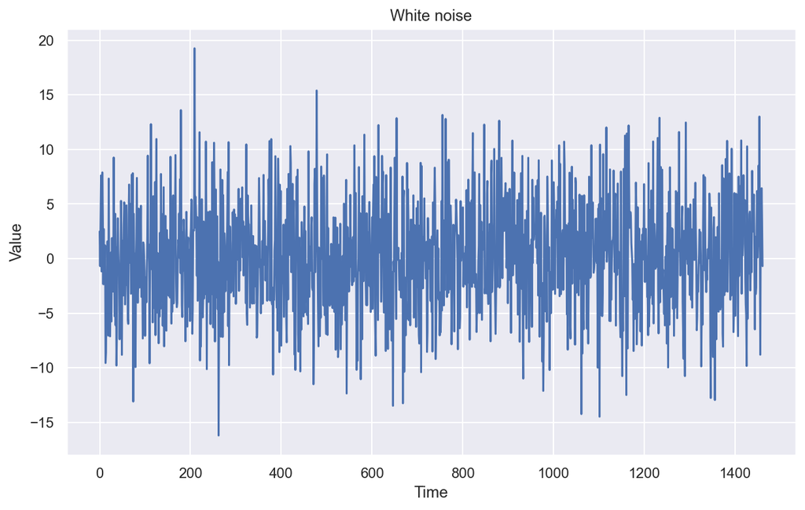

```python
noise_level = 5
noise = white_noise(time, noise_level, seed=42)

plt.title("White noise")
plot_series(time, noise)
plt.show()
```

```python
# summary stats
print(pd.DataFrame(noise).describe())
```

```
0
count  1461.000000
mean      0.225117
std       4.938768
min     -16.206337
25%      -3.127814
50%       0.244300
75%       3.374097
max      19.263657
```

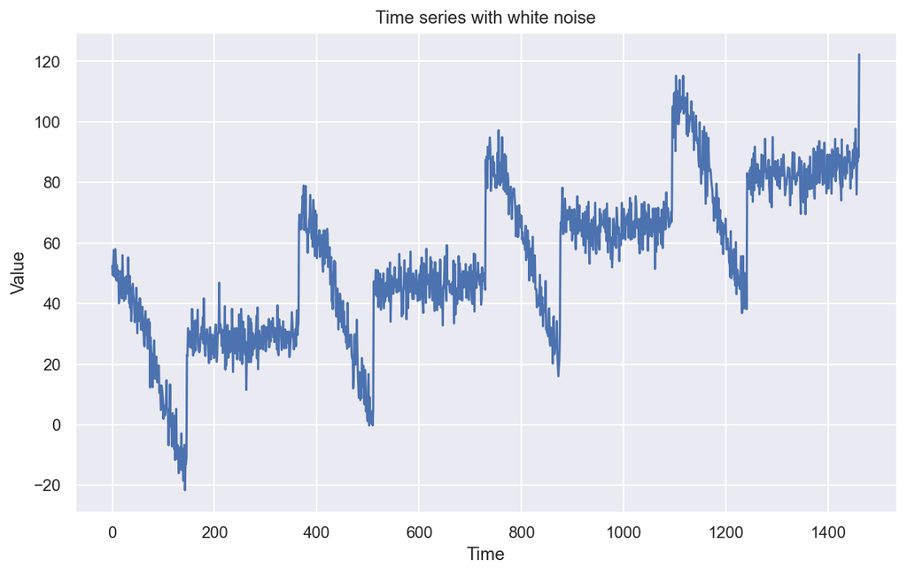

```python
series += noise

plt.title("Time series with white noise")
plot_series(time, series)
plt.show()
```

```python
# summary stats
print(pd.DataFrame(series).describe())
```

```
0
count  1461.000000
mean     53.954441
std      25.399523
min     -21.603769
25%      33.992976
50%      53.336245
75%      73.622013
max     122.307720
```

# Working with real data

As an example, let's look at real mobile game data. Specifically, we will look into ads watched per hour and in-game currency spend per day:

```python
ads = pd.read_csv('ads.csv', index_col=['Time'],
                  parse_dates=['Time'])
currency = pd.read_csv('currency.csv', index_col=['Time'],
                       parse_dates=['Time'])
```

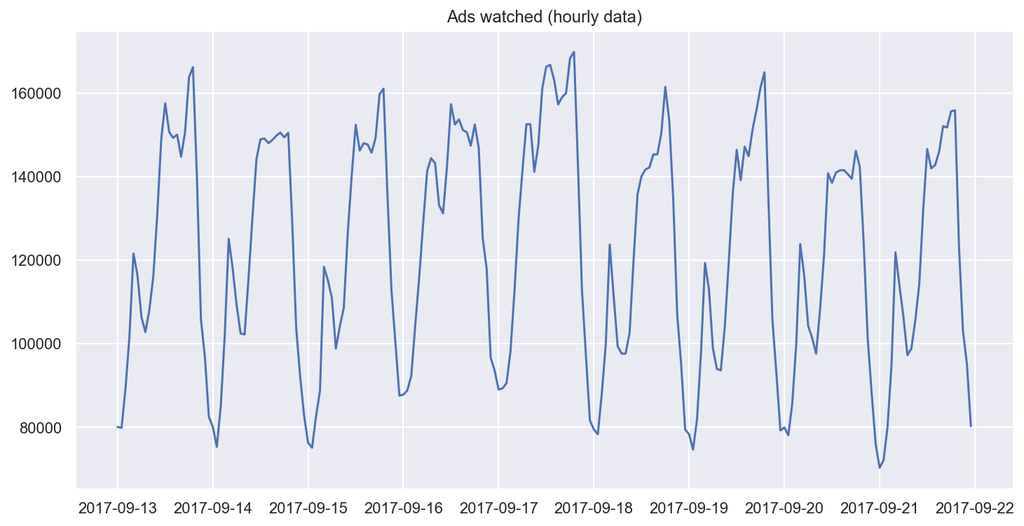

```python
plt.figure(figsize=(12, 6))
plt.plot(ads.Ads)
plt.title('Ads watched (hourly data)')
plt.grid(True)
plt.show()
```

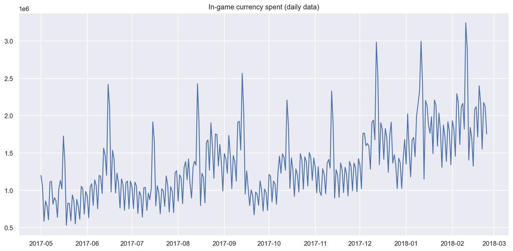

```python
plt.figure(figsize=(15, 7))
plt.plot(currency.GEMS_GEMS_SPENT)
plt.title('In-game currency spent (daily data)')
plt.grid(True)
plt.show()
```